# R Notebook

```r
library(tidyverse)
```

# Question 1

```r
housing_prices <- read_csv("data/housing_prices.csv")
housing_prices
```

| longitude | latitude | housing_median_age | total_rooms | total_bedrooms | population | households | median_income | median_house_value | ocean_proximity |
| --- | --- | --- | --- | --- | --- | --- | --- | --- | --- |
| -122.23 | 37.88 | 41 | 880 | 129 | 322 | 126 | 8.3252 | 452600 | NEAR BAY |
| -122.22 | 37.86 | 21 | 7099 | 1106 | 2401 | 1138 | 8.3014 | 358500 | NEAR BAY |
| -122.24 | 37.85 | 52 | 1467 | 190 | 496 | 177 | 7.2574 | 352100 | NEAR BAY |
| -122.25 | 37.85 | 52 | 1274 | 235 | 558 | 219 | 5.6431 | 341300 | NEAR BAY |
| -122.25 | 37.85 | 52 | 1627 | 280 | 565 | 259 | 3.8462 | 342200 | NEAR BAY |
| -122.25 | 37.85 | 52 | 919 | 213 | 413 | 193 | 4.0368 | 269700 | NEAR BAY |
| -122.25 | 37.84 | 52 | 2535 | 489 | 1094 | 514 | 3.6591 | 299200 | NEAR BAY |
| -122.25 | 37.84 | 52 | 3104 | 687 | 1157 | 647 | 3.1200 | 241400 | NEAR BAY |
| -122.26 | 37.84 | 42 | 2555 | 665 | 1206 | 595 | 2.0804 | 226700 | NEAR BAY |
| -122.25 | 37.84 | 52 | 3549 | 707 | 1551 | 714 | 3.6912 | 261100 | NEAR BAY |

[output cut: 990 more lines]

```r
NA
```

# Question 2

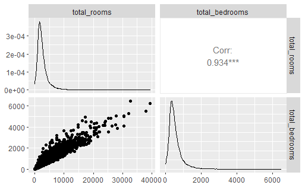

```r
library(GGally)

#ggpairs(housing_prices)
ggpairs(housing_prices[,c("total_rooms", "total_bedrooms")])
```

# Question 3

```r
housing_prices <- housing_prices %>%
  select(-total_bedrooms)
```

# Question 4

## i

Done above

[figure not shown]

```r
housing_prices %>%
  ggpairs()
```

## ii

```r
housing_prices %>%
  summarise(cor = cor(median_income, median_house_value))
```

| cor |
| --- |
| 0.6426108 |

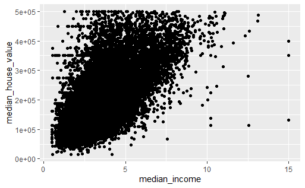

```r
# strong correlation between median_income and median_house_value = 0.642

housing_prices %>%
  ggplot(aes(x= median_income, y = median_house_value)) +
  geom_point()
```

# Question 5

```r
housing_prices %>%
  distinct(ocean_proximity)
```

| ocean_proximity |
| --- |
| NEAR BAY |
| <1H OCEAN |
| INLAND |
| NEAR OCEAN |
| ISLAND |

```r
NA
```

5 distinct ocean_proximity categories therefore we would expect n - 1 dummy variables, i.e. 4 dummy variables for ocean_proximity from this dataset.

# Question 6

```r
model <- lm(median_house_value ~ median_income,
            housing_prices)
```

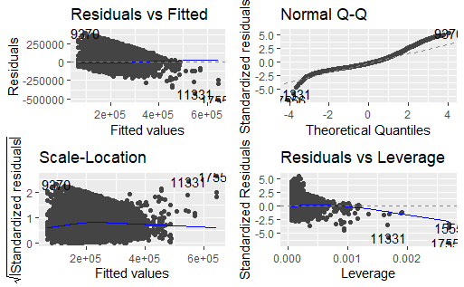

```r
library(ggfortify)

autoplot(model)
```

The plots show that the line of best fit from the model is acceptable.

# Question 7

Add proximity to the beach (categoric variable to the analysis)

```r
library(fastDummies)

housing_prices %>%
  dummy_cols(select_columns = "ocean_proximity",
             remove_first_dummy = TRUE,
             remove_selected_columns = TRUE)
```

| longitude | latitude | housing_median_age | total_rooms | population | households | median_income | median_house_value | ocean_proximity_INLAND | ocean_proximity_ISLAND | ocean_proximity_NEAR BAY | ocean_proximity_NEAR OCEAN |
| --- | --- | --- | --- | --- | --- | --- | --- | --- | --- | --- | --- |
| -122.23 | 37.88 | 41 | 880 | 322 | 126 | 8.3252 | 452600 | 0 | 0 | 1 | 0 |
| -122.22 | 37.86 | 21 | 7099 | 2401 | 1138 | 8.3014 | 358500 | 0 | 0 | 1 | 0 |
| -122.24 | 37.85 | 52 | 1467 | 496 | 177 | 7.2574 | 352100 | 0 | 0 | 1 | 0 |
| -122.25 | 37.85 | 52 | 1274 | 558 | 219 | 5.6431 | 341300 | 0 | 0 | 1 | 0 |
| -122.25 | 37.85 | 52 | 1627 | 565 | 259 | 3.8462 | 342200 | 0 | 0 | 1 | 0 |
| -122.25 | 37.85 | 52 | 919 | 413 | 193 | 4.0368 | 269700 | 0 | 0 | 1 | 0 |
| -122.25 | 37.84 | 52 | 2535 | 1094 | 514 | 3.6591 | 299200 | 0 | 0 | 1 | 0 |
| -122.25 | 37.84 | 52 | 3104 | 1157 | 647 | 3.1200 | 241400 | 0 | 0 | 1 | 0 |
| -122.26 | 37.84 | 42 | 2555 | 1206 | 595 | 2.0804 | 226700 | 0 | 0 | 1 | 0 |
| -122.25 | 37.84 | 52 | 3549 | 1551 | 714 | 3.6912 | 261100 | 0 | 0 | 1 | 0 |

[output cut: 990 more lines]

```r
NA
```

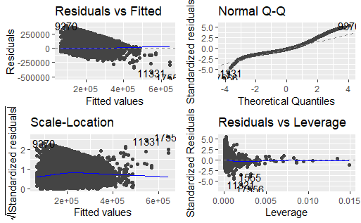

```r
model_income_rooms <- lm(median_house_value ~ median_income + total_rooms,
                       housing_prices)

autoplot(model_income_rooms)
```

```r
summary(model_income_rooms)
```

```
Call:
lm(formula = median_house_value ~ median_income + total_rooms,
    data = housing_prices)

Residuals:
    Min      1Q  Median      3Q     Max
-514229  -51548  -13949   36541  403882

Coefficients:
                Estimate Std. Error t value Pr(>|t|)
(Intercept)    4.552e+04  1.409e+03  32.318   <2e-16 ***
median_income  4.000e+04  3.488e+02 114.679   <2e-16 ***
total_rooms   -4.428e-02  2.511e-01  -0.176     0.86
---
Signif. codes:  0 ‘***’ 0.001 ‘**’ 0.01 ‘*’ 0.05 ‘.’ 0.1 ‘ ’ 1

Residual standard error: 74870 on 19672 degrees of freedom
Multiple R-squared:  0.4129,    Adjusted R-squared:  0.4129
F-statistic:  6919 on 2 and 19672 DF,  p-value: < 2.2e-16
```

```r
model_income_oceanprox <- lm(median_house_value ~ median_income + ocean_proximity,
                housing_prices)

summary(model_income_oceanprox)
```

```
Call:
lm(formula = median_house_value ~ median_income + ocean_proximity,
    data = housing_prices)

Residuals:
    Min      1Q  Median      3Q     Max
-479055  -41086  -11143   27912  376647

Coefficients:
                          Estimate Std. Error t value Pr(>|t|)
(Intercept)                83581.2     1407.7  59.373  < 2e-16 ***
median_income              35118.0      304.8 115.223  < 2e-16 ***
ocean_proximityINLAND     -72313.7     1100.7 -65.695  < 2e-16 ***
ocean_proximityISLAND     200480.2    29232.9   6.858 7.19e-12 ***
ocean_proximityNEAR BAY    16629.7     1591.9  10.446  < 2e-16 ***
ocean_proximityNEAR OCEAN  15552.9     1500.8  10.363  < 2e-16 ***
---
Signif. codes:  0 ‘***’ 0.001 ‘**’ 0.01 ‘*’ 0.05 ‘.’ 0.1 ‘ ’ 1

Residual standard error: 65340 on 19669 degrees of freedom
Multiple R-squared:  0.5529,    Adjusted R-squared:  0.5528
F-statistic:  4865 on 5 and 19669 DF,  p-value: < 2.2e-16
```

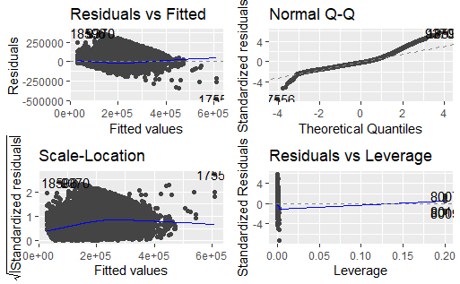

```r
autoplot(model_income_oceanprox)
```

Residual values look ok however the residuals still don’t match perfectly with a normal distribution.

From the summary table there are positive increases in the median house price when the property is located near a bay or ocean with a much larger increase if the property is located on an island, conversely inland properties tend to have lower median house values.

The change in median_house_values can be explained by around 55% from the median_income and ocean_proximity values.

# Question 8

```r
model_log_inc <- lm(log(median_house_value) ~ log(median_income) + ocean_proximity +
                      log(median_income):ocean_proximity,
                    housing_prices)

summary(model_log_inc)
```

```
Call:
lm(formula = log(median_house_value) ~ log(median_income) + ocean_proximity +
    log(median_income):ocean_proximity, data = housing_prices)

Residuals:
     Min       1Q   Median       3Q      Max
-2.26174 -0.21895 -0.02053  0.20040  2.18571

Coefficients:
                                              Estimate Std. Error t value Pr(>|t|)
(Intercept)                                  11.502680   0.011572 993.990  < 2e-16
log(median_income)                            0.571391   0.008457  67.567  < 2e-16
ocean_proximityINLAND                        -0.697405   0.015989 -43.617  < 2e-16
ocean_proximityISLAND                         2.032871   1.038587   1.957   0.0503
ocean_proximityNEAR BAY                      -0.053793   0.025064  -2.146   0.0319
ocean_proximityNEAR OCEAN                    -0.154993   0.023743  -6.528 6.83e-11
log(median_income):ocean_proximityINLAND      0.176592   0.012770  13.829  < 2e-16
log(median_income):ocean_proximityISLAND     -1.277647   1.028706  -1.242   0.2143
log(median_income):ocean_proximityNEAR BAY    0.078022   0.018579   4.200 2.69e-05
log(median_income):ocean_proximityNEAR OCEAN  0.153048   0.018212   8.404  < 2e-16

(Intercept)                                  ***
log(median_income)                           ***
ocean_proximityINLAND                        ***
ocean_proximityISLAND                        .
ocean_proximityNEAR BAY                      *
ocean_proximityNEAR OCEAN                    ***
log(median_income):ocean_proximityINLAND     ***
log(median_income):ocean_proximityISLAND
log(median_income):ocean_proximityNEAR BAY   ***
log(median_income):ocean_proximityNEAR OCEAN ***
---
Signif. codes:  0 ‘***’ 0.001 ‘**’ 0.01 ‘*’ 0.05 ‘.’ 0.1 ‘ ’ 1

Residual standard error: 0.3345 on 19665 degrees of freedom
Multiple R-squared:  0.6068,    Adjusted R-squared:  0.6066
F-statistic:  3372 on 9 and 19665 DF,  p-value: < 2.2e-16
```

The issue may lie with the use of the log being applied to the income value, the income values already appear to be in some transformed state(?).

# Question 8

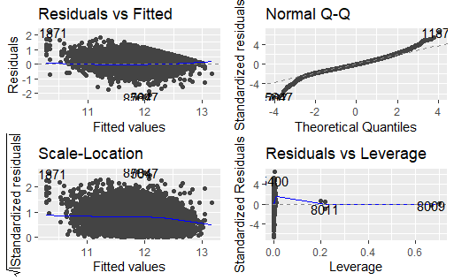

```r
autoplot(model_log_inc)
```

[output not shown]

[output cut: 990 more lines]

# Additional insights

```r
housing_features <- housing_prices %>%
  mutate(rooms_per_house = total_rooms / households,
         bedrooms_per_house = total_bedrooms / households,
         rooms_per_person = total_rooms / population,
         bedrooms_per_person = total_bedrooms / population,
         houses_per_person = households / population,
         prop_bedrooms = total_bedrooms / total_rooms)

library(skimr)

housing_features %>%
  select(rooms_per_house:prop_bedrooms) %>%
  skim()
```

```
── Data Summary ────────────────────────
                           Values
Name                       Piped data
Number of rows             19675
Number of columns          6
_______________________
Column type frequency:
  numeric                  6
________________________
Group variables            None
```

[output not shown]

Set warning = FALSE and message = FALSE to view ggpairs() plots without error messages.

[figure not shown]

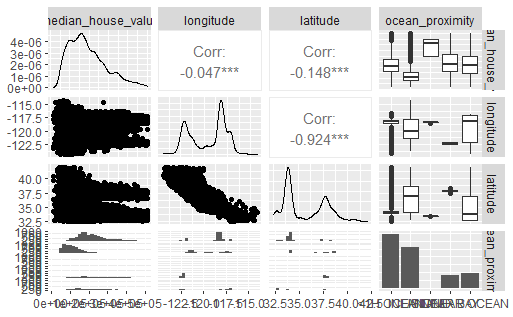

```r
housing_features %>%
  select(median_house_value, longitude, latitude, ocean_proximity) %>%
  ggpairs(progress = FALSE) # progress = FALSE also suppresses progress bar


ggsave("ggpairs2.png",
       width = 12,
       height = 10)
```

```r
housing_features %>%
  select(median_house_value, rooms_per_house:prop_bedrooms) %>%
  ggpairs(progress = FALSE) # progress = FALSE also suppresses progress bar


ggsave("ggpairs3.png",
       width = 12,
       height = 10)
```

[output not shown]

Observations: * median income - very promising - high correlation * ocean proximity - want to explore the levels, 2nd level seems different to the rest, can we group? * houses per person, proportion bedrooms, rooms per house -> potentially useful

[output not shown]

Can we group this?! YES! 2nd level, which had lower distribution of median house value is different - all others are near water.

[output not shown]

```r
ggsave("ggpair4.png",
       width = 12,
       length = 10)
```

[output not shown]

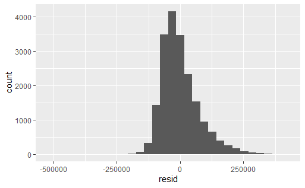

```r
model <- lm(median_house_value ~ median_income,
            housing_features)

library(modelr)
housing_features %>%
  add_residuals(model) %>%
  ggplot(aes(resid)) +
  geom_histogram()
```

Evidence of positive skew

How good is the model? Well, it’s a simple linear model using a variable with r = 0.6 so, we expect r squared of around 0.4 (0.6^2)